# Part II - Ford GoBike Riding Data Presentation

## by Fidelis Mukudi

## Investigation Overview

In this presentation, we will provide the key findings relating to the riding durations of the Ford GoBike. they focus on the riders riding duration, their age, gender, and the start station points.

We found that

- The highest percentage of bike riders are between 25 and 35 years old.
- Three quarters of the rider are males while the female are almost a quarter while the other gender is 2%.
- The majority of the riders ride for less than 5000 seconds and are aged between 25 and 35 years. The majority of Riders riding for longer hours are within the same age bracket. A few elders beyond 70 years ride for more than 10000 seconds.
- On average the male ride for a shorter period than the female and the other gender.
- In general, start stations having the highest number of riders do not have highest average riding durations.

## Dataset Overview

The project was about creating visualization for Ford GoBike System Data . The data contains details rides of different people of different age and sex from different start stations. It has 183412 rows and 16 columns. The variable of interest is the duration of riding. We have provided the findings on how the duration of riding varies with different variables such as age, sex and start_station_id.

## Distribution of age among the riders

The highest percentage of bike riders are between 25 and 35 years old.

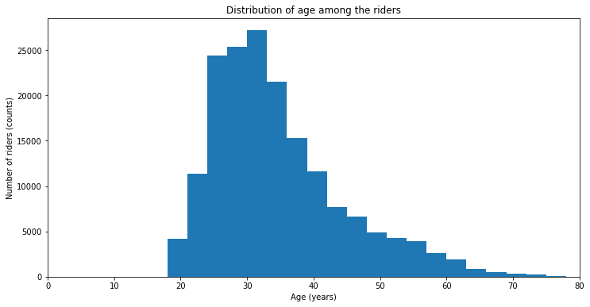

## Distribution of gender among the riders

Three quarters of the rider are males. The Female are almost a quarter while the other gender is 2%.

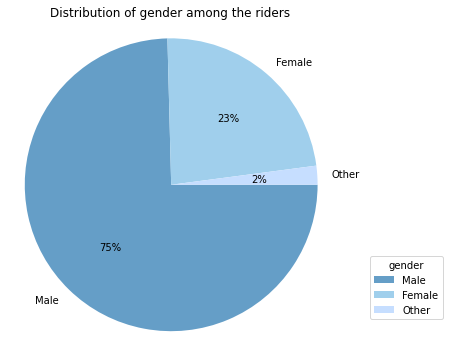

## Association of age and duration of riding

The majority of the riders ride for less than 5000 seconds and are aged between 25 and 35 years. The majority of riders ridding for longer hours are within the same age bracket. A few elders beyond 70 years ride for more than 10000 seconds.

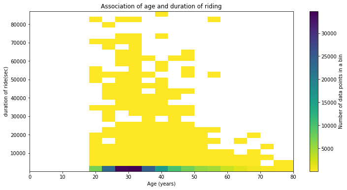

On average the male ride for a shorter period than the female and the other gender.

In general, start stations having the highest number of riders do not have highest average riding durations. This implies that on average, the majority of the riders from the commonly used starting stations ride for shorter periods of time.

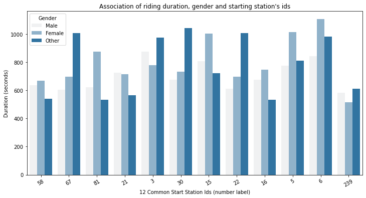